# Reproducible Research peer assessment 1

## Load the data

```r
data=read.csv("activity.csv")
```

### What the data is !

```r
summary(data)
```

```
##      steps               date          interval
##  Min.   :  0.0   2012-10-01:  288   Min.   :   0
##  1st Qu.:  0.0   2012-10-02:  288   1st Qu.: 589
##  Median :  0.0   2012-10-03:  288   Median :1178
##  Mean   : 37.4   2012-10-04:  288   Mean   :1178
##  3rd Qu.: 12.0   2012-10-05:  288   3rd Qu.:1766
##  Max.   :806.0   2012-10-06:  288   Max.   :2355
##  NA's   :2304    (Other)   :15840
```

## What is mean total number of steps taken per day?

### 1.Calculate the total number of steps taken per day

```r
da=with(data,aggregate(steps,by=list(date=date),sum,na.rm=T))
```

#### We can know the the total number of steps taken per day is :

```r
da
```

```
##          date     x
## 1  2012-10-01     0
## 2  2012-10-02   126
## 3  2012-10-03 11352
## 4  2012-10-04 12116
## 5  2012-10-05 13294
## 6  2012-10-06 15420
## 7  2012-10-07 11015
## 8  2012-10-08     0
## 9  2012-10-09 12811
## 10 2012-10-10  9900
## 11 2012-10-11 10304
## 12 2012-10-12 17382
## 13 2012-10-13 12426
## 14 2012-10-14 15098
```

[output cut: 47 more lines]

### 2.If you do not understand the difference between a histogram and a barplot, research the difference between them. Make a histogram of the total number of steps taken each day.

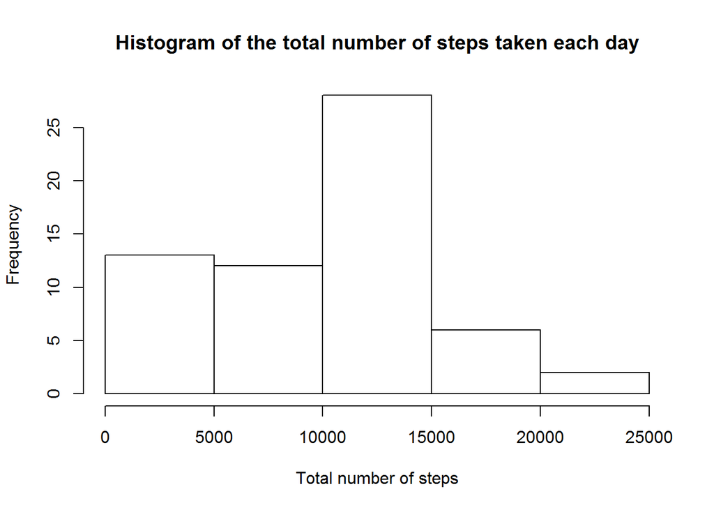

```r
hist(da$x,main="Histogram of the total number of steps taken each day",xlab="Total number of steps")
```

### 3.Calculate and report the mean and median of the total number of steps taken per day

#### We can use the aggregate calculate the mean and median,so:

```r
mean.median=with(data[!is.na(data$steps),],aggregate(steps,by=list(date=date),function(x){c(mean=mean(x,na.rm=T),median=median(x,na.rm=T))}))
```

```r
mean.median
```

```
##          date  x.mean x.median
## 1  2012-10-02  0.4375   0.0000
## 2  2012-10-03 39.4167   0.0000
## 3  2012-10-04 42.0694   0.0000
## 4  2012-10-05 46.1597   0.0000
## 5  2012-10-06 53.5417   0.0000
## 6  2012-10-07 38.2465   0.0000
## 7  2012-10-09 44.4826   0.0000
## 8  2012-10-10 34.3750   0.0000
## 9  2012-10-11 35.7778   0.0000
## 10 2012-10-12 60.3542   0.0000
## 11 2012-10-13 43.1458   0.0000
## 12 2012-10-14 52.4236   0.0000
## 13 2012-10-15 35.2049   0.0000
## 14 2012-10-16 52.3750   0.0000
```

[output cut: 39 more lines]

## What is the average daily activity pattern?

#### 1.Calculate the 5-minute interval the average number of steps taken:

```r
interval.5=with(data,aggregate(steps,by=list(interval=interval),mean,na.rm=T))
```

#### Then ,plot the series plot

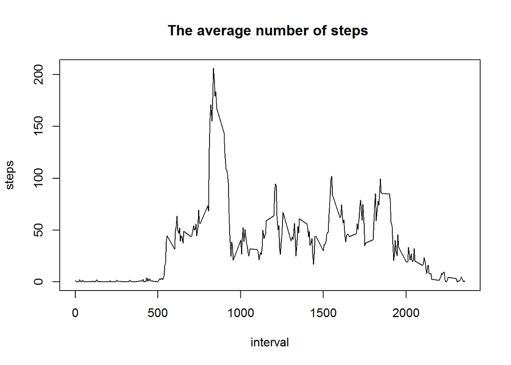

```r
plot( interval.5,type='l',ylab="steps",main="The average number of steps ")
```

## Imputing missing values

### 1. we can know the total number of rows with NAs is : 2304

### 2.Devise a strategy for filling in all of the missing values in the dataset with the mean of 5-minute interval

#### So,we can Create a new dataset that is equal to the original dataset but with the missing data filled in with the mean of 5-minute interval

```r
na.label=which(is.na(data$steps))
new.data=data
na.values=sapply(data$interval[na.label],function(x,data2){data2$x[data2$interval==x]},data2=interval.5)
new.data$steps[na.label]=na.values
```

### 3.Make a histogram of the total number of steps taken each day

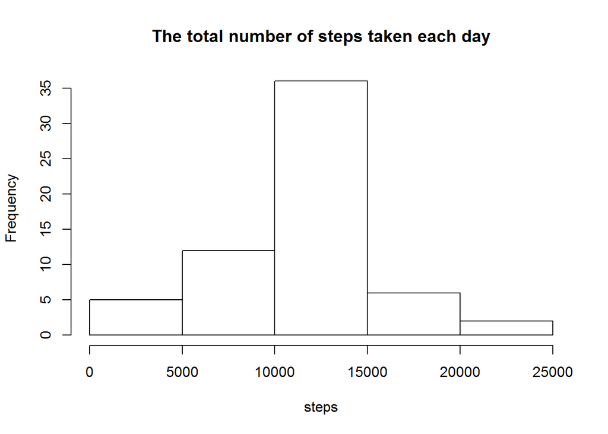

```r
steps.day=with(new.data,aggregate(steps,by=list(date=date),sum,na.rm=T))
hist(steps.day$x,main="The total number of steps taken each day",xlab="steps")
```

### The mean and median total number of steps taken per day

```r
new.mean.median=with(new.data,aggregate(steps,by=list(date=date),function(x){c(mean=mean(x),median=median(x))}))
```

#### we can see the mean and median is :

```r
new.mean.median
```

```
##          date  x.mean x.median
## 1  2012-10-01 37.3826  34.1132
## 2  2012-10-02  0.4375   0.0000
## 3  2012-10-03 39.4167   0.0000
## 4  2012-10-04 42.0694   0.0000
## 5  2012-10-05 46.1597   0.0000
## 6  2012-10-06 53.5417   0.0000
## 7  2012-10-07 38.2465   0.0000
## 8  2012-10-08 37.3826  34.1132
## 9  2012-10-09 44.4826   0.0000
## 10 2012-10-10 34.3750   0.0000
## 11 2012-10-11 35.7778   0.0000
## 12 2012-10-12 60.3542   0.0000
## 13 2012-10-13 43.1458   0.0000
## 14 2012-10-14 52.4236   0.0000
```

[output cut: 47 more lines]

#### So ,we can know these values differ from the estimates from the first part of the assignment

#### So,we can know the impact of imputing missing data on the estimates of the total daily number of steps that the devices maybe not work or the devices is left out from the body.

## Are there differences in activity patterns between weekdays and weekends?

```r
week.label=weekdays(seq(as.Date("2011-01-01"),as.Date("2011-01-07"),by=1))

new.data$week=sapply(weekdays(as.Date(new.data$date)),
                     function(x){if(x %in% week.label[3:7])
                               return("weekday")
                               else
                              return("weekend")})
```

#### Calculate the 5-minute interval the average number of steps taken

```r
week.steps=with(new.data,aggregate(steps,by=list(interval=interval,week=week),mean))
library(lattice)
```

#### Make a panel plot containing a time series plot is :

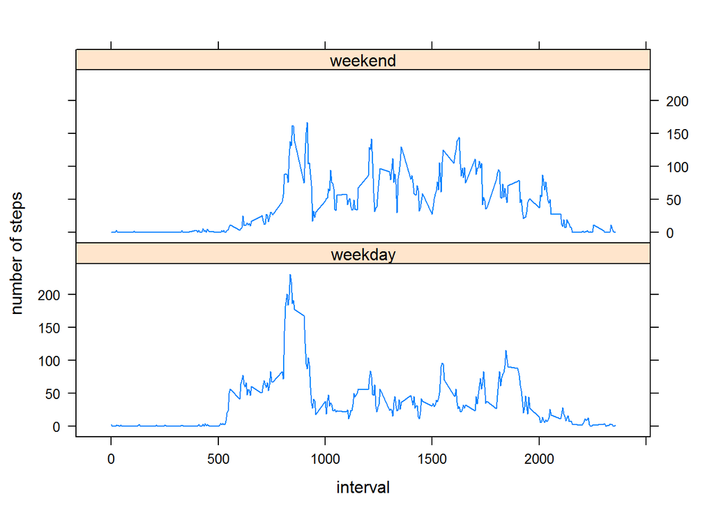

```r
xyplot(x~interval|week,data=week.steps,layout=c(1,2),ylab=" number of steps ",type='l')
```